# Clustering methods on number of accidents for OECD countries (Part 1)

Maria Janiszewska

### Introduction

This paper is one of the two analysis that I created based on the number of accidents in OECD countries. I would like to present here analysis of car accidents with injured people. Method used: k-means and PAM. Dataset comes from https://stats.oecd.org. It contains number of car accidents in OECD countries by year. The aim of this analysis is to check, whether we can divide countries based on their changes in number of car accidents through the years.

Here is a list of packages used in the analysis.

```r
library(unikn)
library(RColorBrewer)
library(NbClust)
library(lattice)
library(reshape2)
library(cluster)
library(factoextra)
library(flexclust)
library(fpc)
library(clustertend)
library(ClusterR)
library(clusterSim)
```

### Dataset - preparation and cleaning

In order to conduct analysis I decided to change structure of the data, leaving Countries (rows) and get years as columns. Also there was 2 types of data - Road casualties (injured + killed) and Road injury accidents, so I left only the latter.  
At first where was 55 observations, but after transformation there are 44 left.

```r
# Prepared dataset
head(data)
```

```
##    2000  2001  2002  2003  2004  2005  2006  2007  2008  2009  2010  2011  2012
## 1   428   400   328   363   801   850  1015  1254  1208  1465  1564  1876  1870
## 4 42126 43073 43175 43426 42657 40896 39884 41096 39173 37925 35348 35129 40831
## 5  1987  1985  2193  2311  2388  3179  3197  3104  2970  2792  2721  2890  2892
## 6  6410  6329  7204  7194  7218  7717  8283  7501  7238  6739  6363  5897  5187
## 7 49065 47444 47619 50479 48670 48968 49008 49618 48703 47619 45745 47761 44259
## 9  6886  6709  6769  6997  7612  8224  8222  8010  8045  7068  6609  6639  6717
##    2013  2014  2015  2016  2017  2018
## 1  2075  1914  1992  2033  1978  1718
## 4 38502 37957 37960 38466 37402 36846
## 5  2846  2635  2220  2006  1833  1817
## 6  4730  4550  4151  3654  3418  3399
## 7 41347 41474 40300 40123 38025 38455
## 9  7015  7018  7225  7404  6888  6684
```

### Analysis

First I checked weather the data is clusterable. I used Hopkins statistics and Ordered Dissimilarity Matrix (ODM) to do so.

```r
# Hopkins statistic
hopkins(data, n=nrow(data)-1)
```

```
## $H
## [1] 0.02630883
```

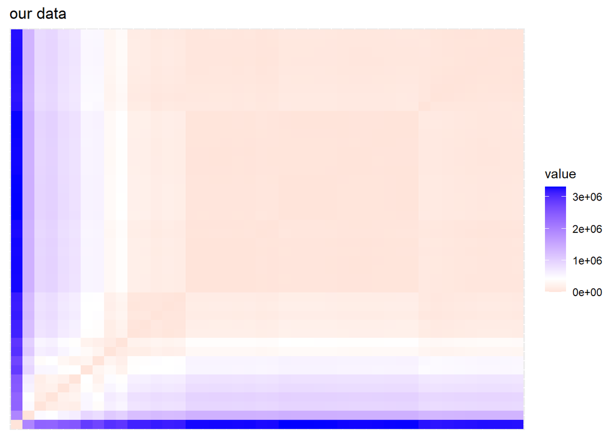

```r
# ODM
d<-dist(data)
d<-get_dist(data, method="euclidean")
fviz_dist(d, show_labels = FALSE)+ labs(title="our data")
```

#### Number of clusters

To check how many clusters to create I looked at the two measures, that are often used to identifying numbers of clusters. These are: silhouette and Adjusted R Squared.

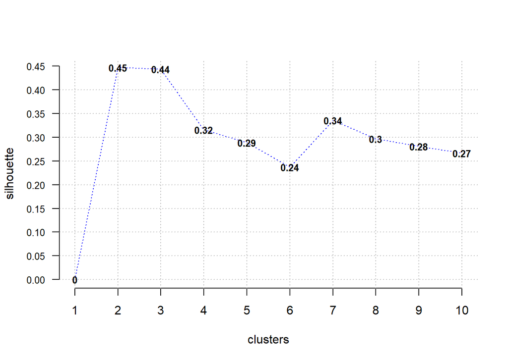

```r
opt<-Optimal_Clusters_KMeans(data, max_clusters=10, plot_clusters=TRUE, criterion="silhouette")
```

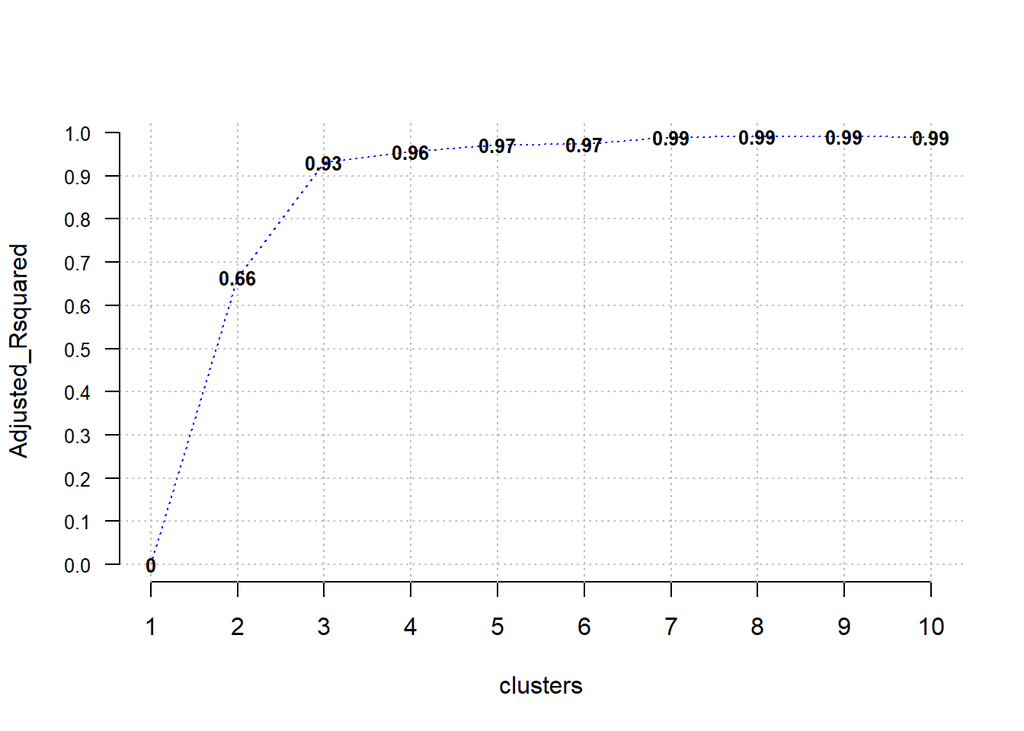

```r
opt<-Optimal_Clusters_KMeans(data, max_clusters=10, plot_clusters=TRUE, criterion="Adjusted_Rsquared")
```

First plot shows optimal number of clusters based on silhouette. We can conclude that according to this picture we should use two or three clusters, because they have similar values.  
The second plot shows that two clusters give quite good results, but a better idea is to use 3 clusters, because every next cluster do not significantly improve the results.

#### Distance

After selecting the number of cluster, let’s choose which distance metrics will be better for this kind of data. To check it we can look at the picture below, which shows each observation’s distance from the centroid measured Euclidean and Manhattan metrics.

```r
d1<-cclust(data, 3, dist="euclidean")
d2<-cclust(data, 3, dist="manhattan")
```

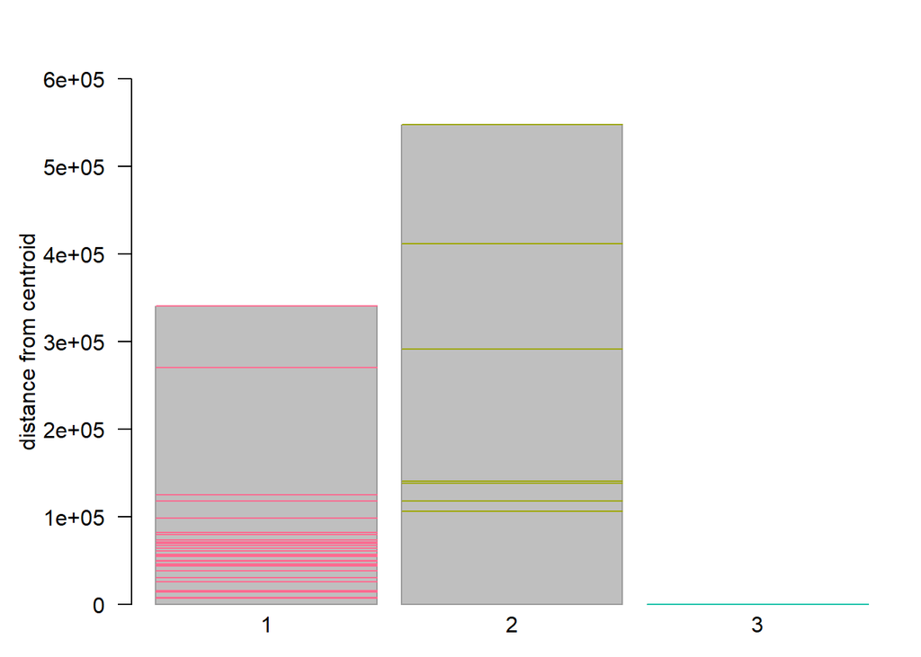

```r
stripes(d1)
```

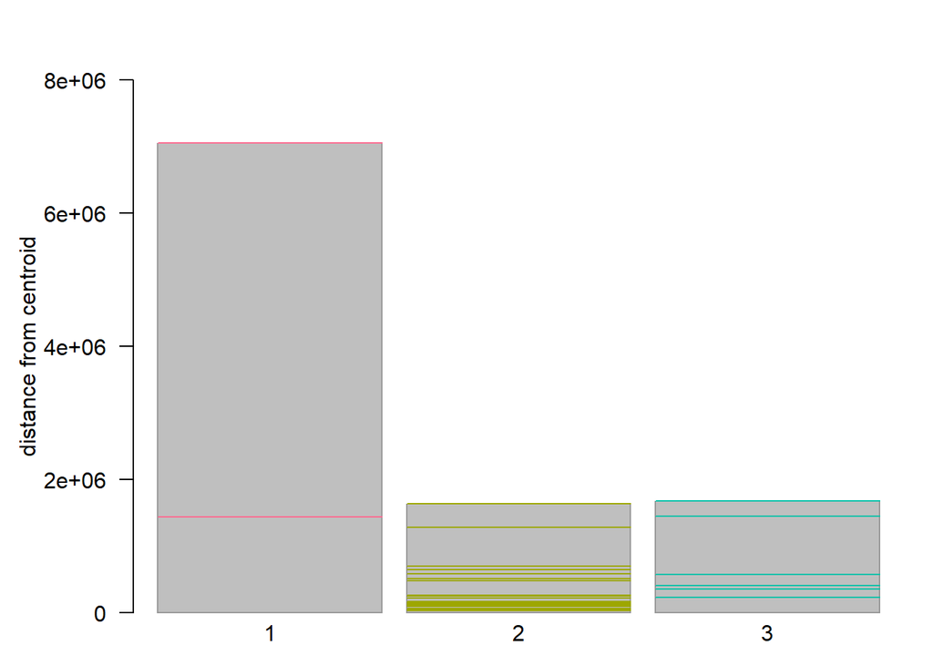

```r
stripes(d2)
```

Basically the lower are the bars - the smaller distance is from an observation to the centroid. As we can see on the bar plots above - higher values are for the Manhattan distance. Based on this information we choose Euclidean distance metrics for further analysis.  
It is worth mentioning that we should look at the scale, because for the Manhattan metrics it looks like two clusters (2 and 3) are more grouped to each other, but in reality the lower distance is for Euclidean.

Additionally we can see that the clusters are not equal. It seems that there are one or two observations that seems to be significantly different from others. To check if removing this observation will improve clustering, we will conduct one clustering for all data, and one for data without this observation.

#### **K MEANS**

One of the two methods of clustering that I used here is k-means. This is the most popular way to grouping the data. It gathers these observations that are similar to each other.  
As I discussed above I used the Euclidean distance metrics for 3 clusters and additionally 4 to see the differences between using different number of clusters.

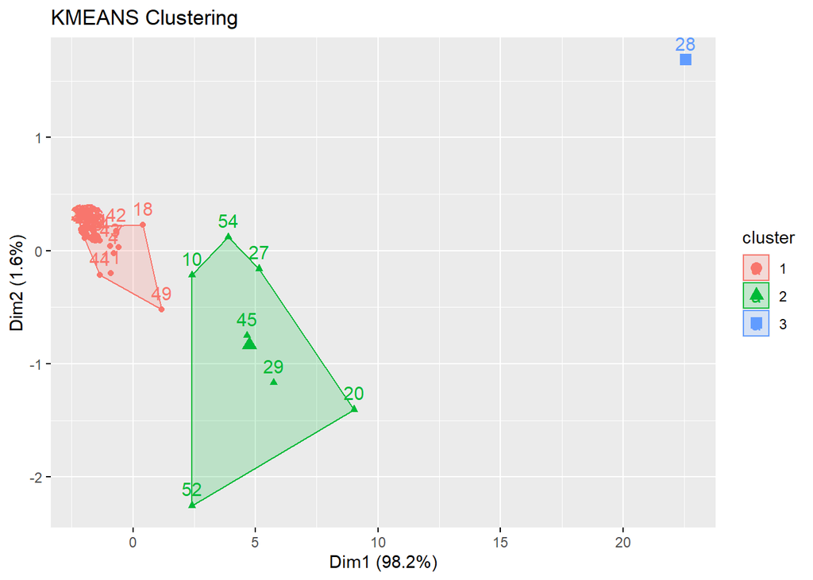

```r
km1<-eclust(data, "kmeans", hc_metric="euclidean",k=3)
```

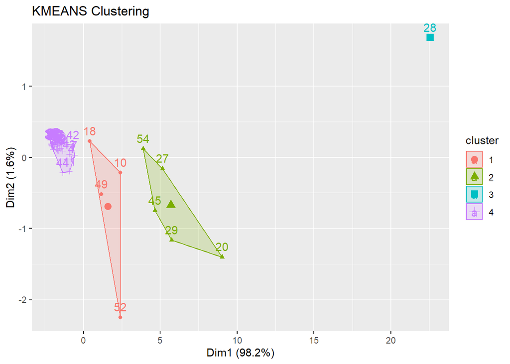

```r
km2<-eclust(data, "kmeans", hc_metric="euclidean",k=4)
```

The first thing that we see on the cluster plots is the outlier (number 28 - Japan), which is significantly different from other observations, which confirms previous findings. The rest of observations are diversified. There are a lot of observations that are concentrated in one cluster, whereas there are few more that are quite far from each other. Adding one more cluster helps to join them, but there is a question - Does it improve clustering?  
In the table below we can see to which cluster every observation is assigned.

```r
km2$cluster
```

```
##  1  4  5  6  7  9 10 11 13 14 15 16 17 18 19 20 21 22 23 25 26 27 28 29 30 31
##  4  4  4  4  4  4  1  4  4  4  4  4  4  1  4  2  4  4  4  4  4  2  3  2  4  4
## 32 33 36 39 40 41 42 43 44 45 46 47 48 49 50 51 52 54
##  4  4  4  4  4  4  4  4  4  2  4  4  4  1  4  4  1  2
```

#### Tests

To check wheather adding one more cluster improve results I used Calinski-Harabasz (CH) index also known as Variance Ratio Criterion and Davies-Bouldin index as a comparison. Results are presented below.

##### Calinski-Harabasz index

```r
round(calinhara(data, km1$cluster),digits=2)
```

```
## [1] 293.24
```

```r
round(calinhara(data, km2$cluster),digits=2)
```

```
## [1] 388.73
```

Calinski-Harabasz statistics is much higher for the second scenario with 4 clusters. This means that adding one cluster improves quality of the clustering. This is not consistent with previous results based on which we concluded that the best number of clusters is 3.

##### Davies-Bouldin index

```r
index.DB(data, km1$cluster, d=NULL, centrotypes="centroids", p=2, q=2)$DB
```

```
## [1] 0.3659853
```

```r
index.DB(data, km2$cluster, d=NULL, centrotypes="centroids", p=2, q=2)$DB
```

```
## [1] 0.5011754
```

Davies-Bouldin index is a measure that compares the distance between clusters with the size of the clusters themselves. In contrast to the CH index, here we seek for the lower value of index. In this case we can see that 3 cluster separation seems to be a better idea. This situation may happen when data set is hard to conduct clustering. However for now I stayed at the Calinski-Harabasz result.

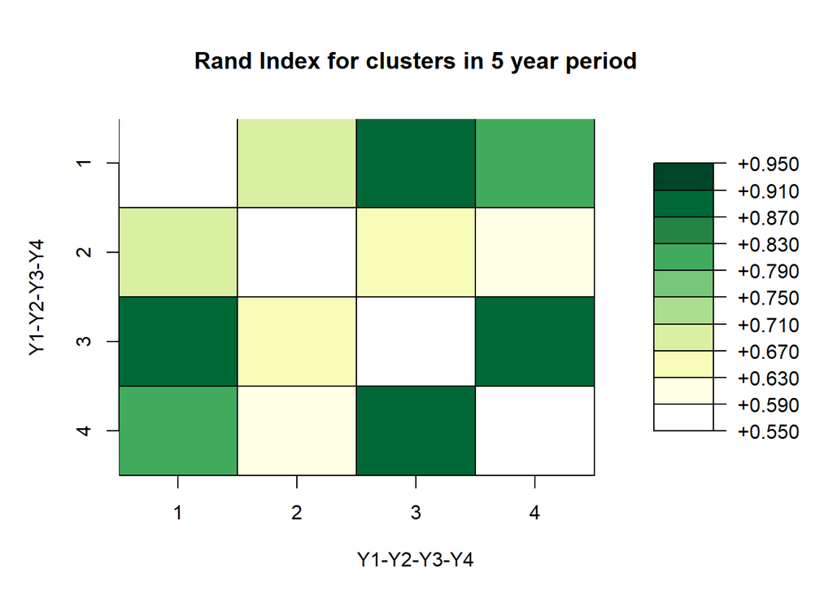

```r
set.per1<-data[,1:5]
set.per2<-data[,6:10]
set.per3<-data[,11:15]
set.per4<-data[,16:19]

Y1<-cclust(set.per1, 4, dist="euclidean")
Y2<-cclust(set.per2, 4, dist="euclidean")
Y3<-cclust(set.per3, 4, dist="euclidean")
Y4<-cclust(set.per4, 4, dist="euclidean")

par(mar=c(5,5,5,5))

p6<-brewer.pal(n=9, name="YlGn")
mix6<-usecol(pal=c("white", p6))

vec.coef<-c("Y1", "Y2", "Y3", "Y4")
tab.ri<-matrix(0, nrow=4, ncol=4)

for(i in 1:4){
  for(j in 1:4){
    rix<-randIndex(get(vec.coef[i]), get(vec.coef[j]))
    tab.ri[i,j]<-rix}}
diag(tab.ri)<-NA

library(plot.matrix)

plot(tab.ri, col=mix6, main="Rand Index for clusters in 5 year period", xlab="Y1-Y2-Y3-Y4", ylab="Y1-Y2-Y3-Y4")
```

#### Removing outlier

To see weather we should delete an observation that is significantly different from the others, I created new clustering for the new data set without Japan.

Firstly let’s check how many clusters are recommended by the 2 criteria.

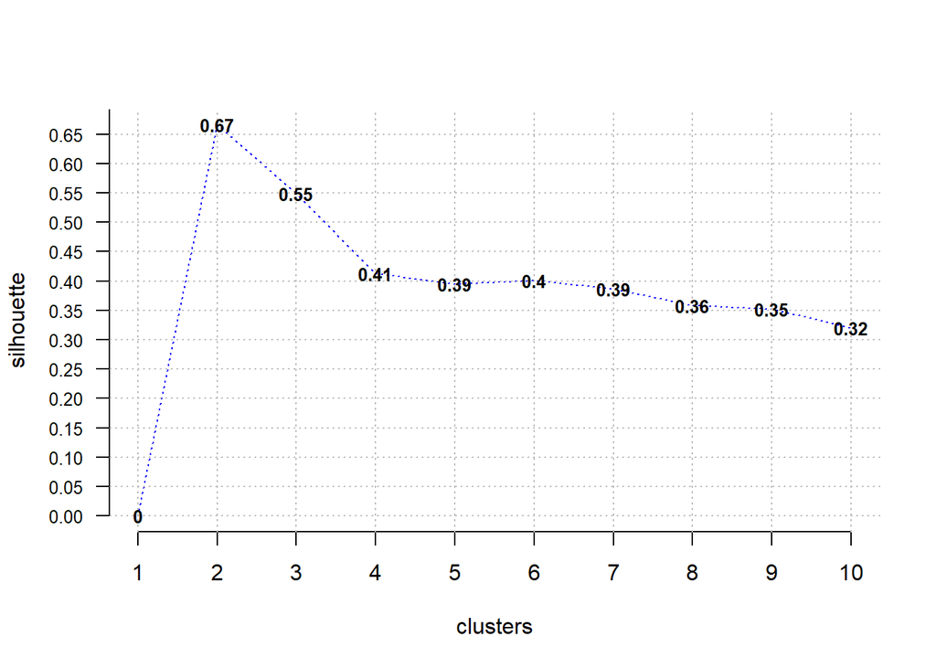

```r
opt<-Optimal_Clusters_KMeans(data_no_japan, max_clusters=10, plot_clusters=TRUE, criterion="silhouette")
```

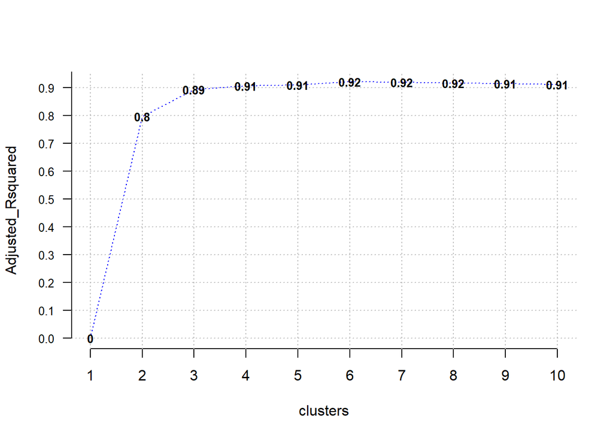

```r
opt<-Optimal_Clusters_KMeans(data_no_japan, max_clusters=10, plot_clusters=TRUE, criterion="Adjusted_Rsquared")
```

Based on the plots we conclude that the best number of clusters is 2. This means that keeping outlier will generate need of one more cluster for this observation, but the rest can be divided in two groups.  
Plot below presents visualization of the clustering in two and three clusters.

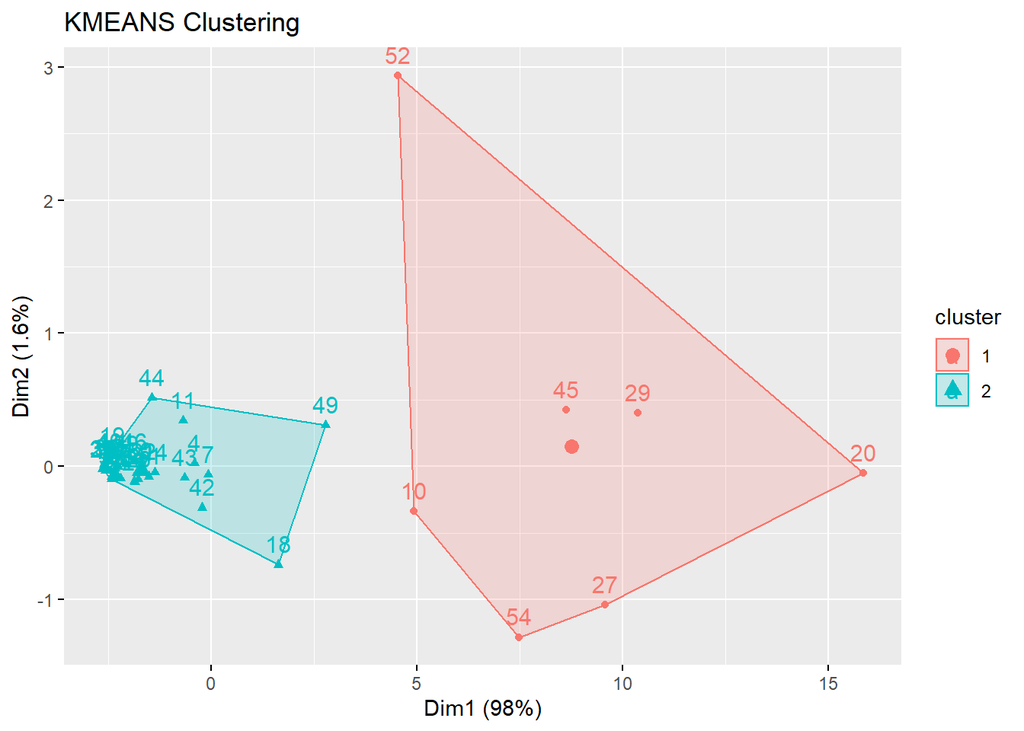

```r
km11<-eclust(data_no_japan, "kmeans", hc_metric="euclidean",k=2)
```

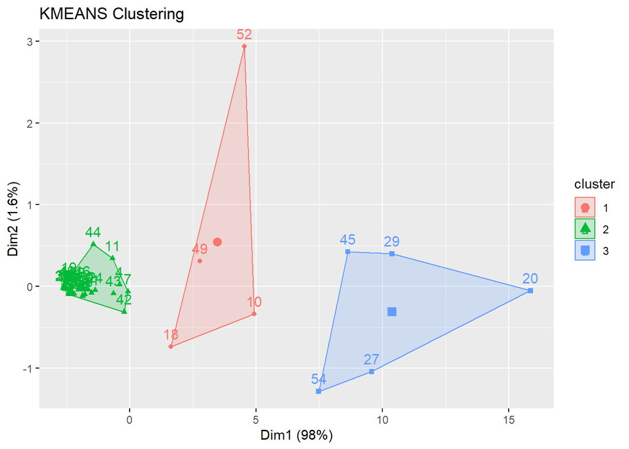

```r
km22<-eclust(data_no_japan, "kmeans", hc_metric="euclidean",k=3)
```

We can see that observations in clusters are the same as previous with one additional one for the outlier.  
Let’s see if the conclusion that 3 clusters (in previous case 4 because of the not-deleted observation) are better than 2. To to this we use Calinski-Harabasz index.

```r
round(calinhara(data_no_japan, km11$cluster),digits=2)
```

```
## [1] 164.7
```

```r
round(calinhara(data_no_japan, km22$cluster),digits=2)
```

```
## [1] 177.7
```

Surprisingly value of statistic is higher for more number of clusters. It can be a good idea to check Davies-Bouldin index.

```r
index.DB(data_no_japan, km11$cluster, d=NULL, centrotypes="centroids", p=2, q=2)$DB
```

```
## [1] 0.4889195
```

```r
index.DB(data_no_japan, km22$cluster, d=NULL, centrotypes="centroids", p=2, q=2)$DB
```

```
## [1] 0.6348032
```

In this case value of DB index is lower for 2 clusters. So again the result are opposite to Calinski-Harabasz index.

#### Predictions

To see if there we can predict in which cluster the new observation will belong I prepared an experiment. Firstly we divide data into training set and test set in which there will be observations number 19 (Georgia) and 27 (Italy). K-means for 4 clusters with euclidean measure.

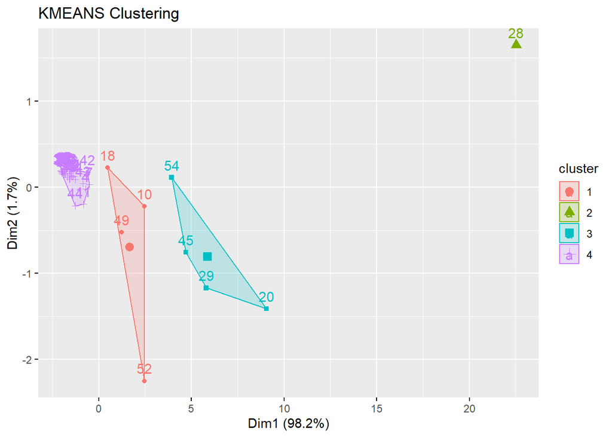

```r
km.train<-eclust(set.train, "kmeans", hc_metric="euclidean",k=4)
```

```r
km.train.kcca<-as.kcca(km.train, set.train)
km.pred<-predict(km.train.kcca, set.test)
km.pred
```

```
## 19 27
##  4  3
```

#### **PAM**

Another popular method of clustering is PAM. It works similar to CLARA algorithm however is designed to small data set. CLARA is for a huge ones and can deal with them by working on samples which in this case will be not efficient.

#### Number of clusters

Keepeing in mind that k-means were divided in 3 and 4 clusters we check if it also work for PAM method. We used automated function for PAM clustering which is based on criterion average silhouette width (ASW) and the result is presented below.

```r
pamk.best<-pamk(data, krange=2:10,criterion="asw", usepam=TRUE, scaling=FALSE, alpha=0.001, diss=inherits(data, "dist"), critout=FALSE)
pamk.best$nc
```

```
## [1] 3
```

Automated function, which is based on the ASW criterion confirms previous conclusions. Thus we will use 3 clusters to analyze the data.Keeping in mind that in k-means analysis we also used 3 clusters at the beginning, but see what will happen with 4 clusters.

#### Clustering

Lets’s see how grouping looks like for 3 and 4 clusters.

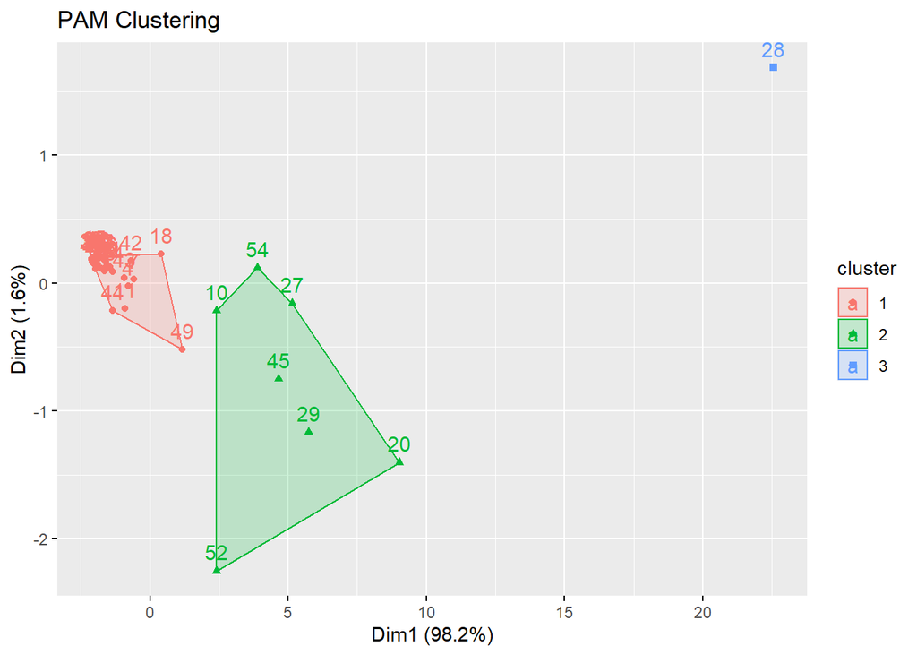

```r
pam1<-eclust(data, "pam", k=3, hc_metric="euclidean")
```

```
##   cluster size ave.sil.width
## 1       1   36          0.88
## 2       2    7          0.46
## 3       3    1          0.00
```

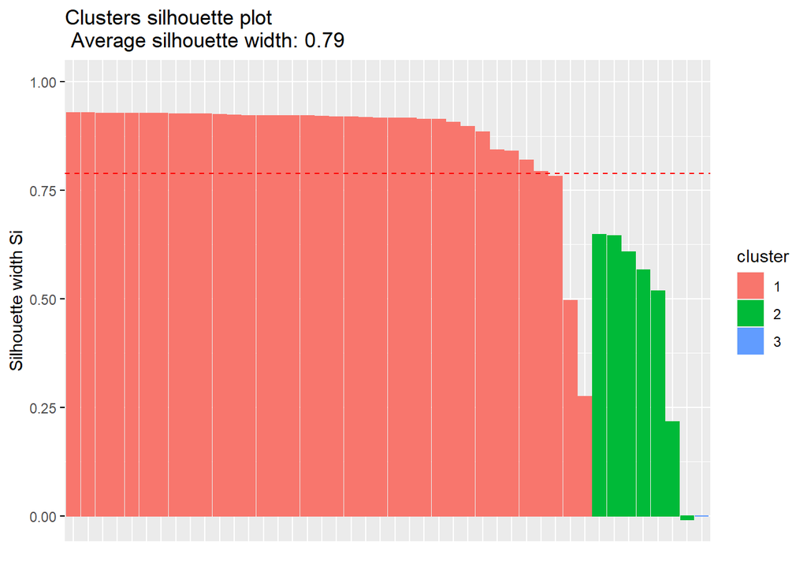

```r
fviz_silhouette(pam1)
```

```r
pam1$clustering
```

```
##  1  4  5  6  7  9 10 11 13 14 15 16 17 18 19 20 21 22 23 25 26 27 28 29 30 31
##  1  1  1  1  1  1  2  1  1  1  1  1  1  1  1  2  1  1  1  1  1  2  3  2  1  1
## 32 33 36 39 40 41 42 43 44 45 46 47 48 49 50 51 52 54
##  1  1  1  1  1  1  1  1  1  2  1  1  1  1  1  1  2  2
```

As we can see above PAM for 3 clusters looks very similar to k-means method. The outlier has its own cluster and there are 2 more, one with most of the observations. The thing that is important is average silhouette for 3 clusters. It is equal to 0, which is caused by only one observation in cluster. Low value is also for second cluster and it’s equal to 0.46.

We can find also specifics of clustering each observations.

To compare results I prepared also PAM for 4 clusters. As we can see the observations from the 1 cluster are still in the same group and from the other are divided in 2 separate. Value of silhouette for them is low but not drastically different from scenario with 3 cluster - still do not reach 0.75. Looking at the value of average silhouette off all clusters - less clusters is better.

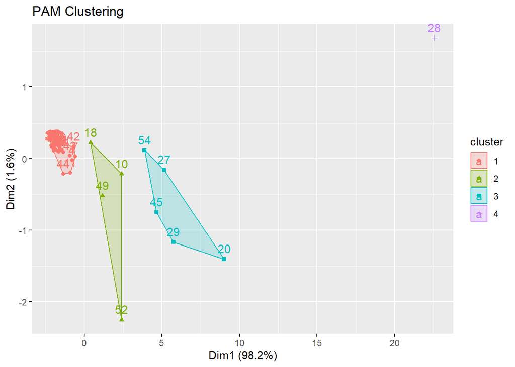

```r
pam2<-eclust(data, "pam", k=4, hc_metric="euclidean")
```

```
##   cluster size ave.sil.width
## 1       1   34          0.84
## 2       2    4          0.41
## 3       3    5          0.40
## 4       4    1          0.00
```

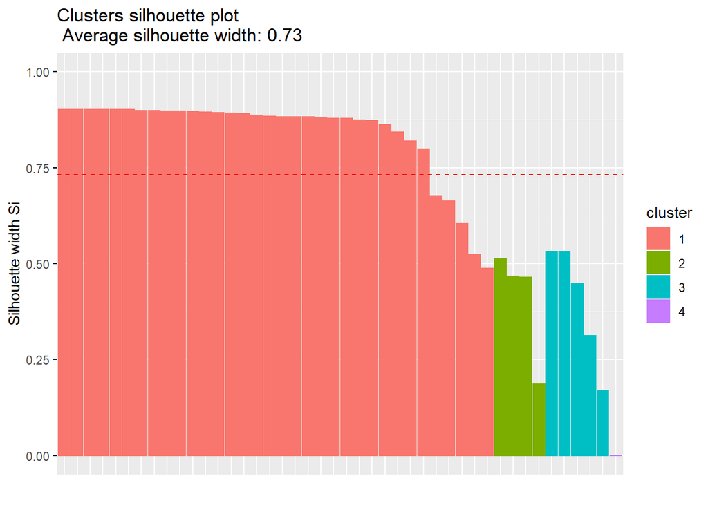

```r
fviz_silhouette(pam2)
```

```r
pam2$clustering
```

```
##  1  4  5  6  7  9 10 11 13 14 15 16 17 18 19 20 21 22 23 25 26 27 28 29 30 31
##  1  1  1  1  1  1  2  1  1  1  1  1  1  2  1  3  1  1  1  1  1  3  4  3  1  1
## 32 33 36 39 40 41 42 43 44 45 46 47 48 49 50 51 52 54
##  1  1  1  1  1  1  1  1  1  3  1  1  1  2  1  1  2  3
```

#### Tests

To see which number of clusters is better we used Calinski-Harabasz index. The values are presented below.

```r
round(calinhara(data, pam1$cluster),digits=2)
```

```
## [1] 293.24
```

```r
round(calinhara(data, pam2$cluster),digits=2)
```

```
## [1] 388.73
```

As we can see value of CH index is higher for scenario with 4 clusters. This means that it can be a good idea to use 4 clusters instead of 3. So looking only on the silhouette may can lead to different conclusions.

```r
index.DB(data, pam1$cluster, d=NULL, centrotypes="centroids", p=2, q=2)$DB
```

```
## [1] 0.3659853
```

```r
index.DB(data, pam2$cluster, d=NULL, centrotypes="centroids", p=2, q=2)$DB
```

```
## [1] 0.5011754
```

#### Removing outlier

Now let’s check whether removing an outlier will improve clustering.  
First check how many clusters is the best. Looking at the plot below we can conclude that 2 clusters will be good enough.

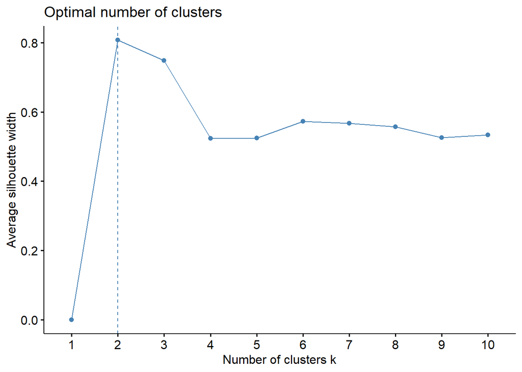

```r
fviz_nbclust(data_no_japan, FUNcluster=cluster::pam)
```

First two plots are for 2 clusters. We can see that observations are in the same clusters as before. However removing the outlier (which silhouette was equal to 0) increased average silhouette value up to 0.81.

Increasing number of cluster in this case did not make clustering better. Now the average silhouette is lower.

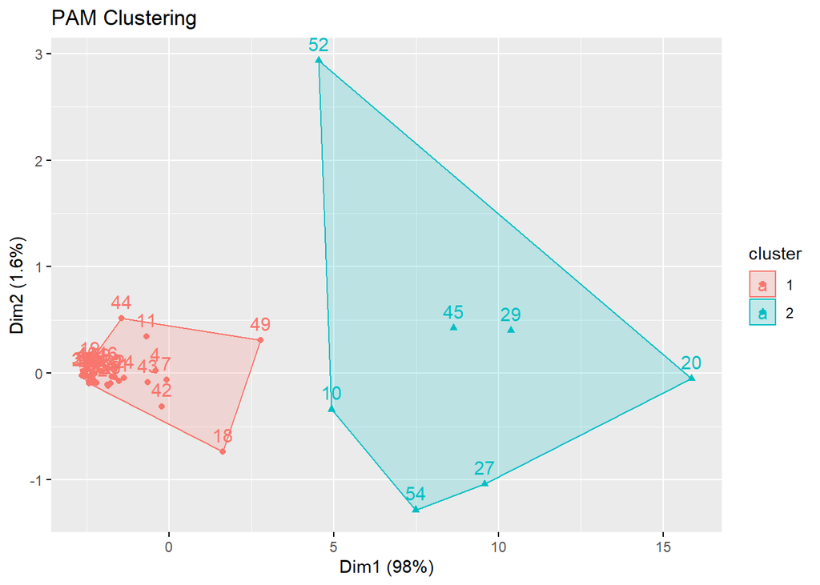

```r
pam_jap1<-eclust(data_no_japan, "pam", k=2, hc_metric="euclidean")
```

```
##   cluster size ave.sil.width
## 1       1   36          0.88
## 2       2    7          0.46
```

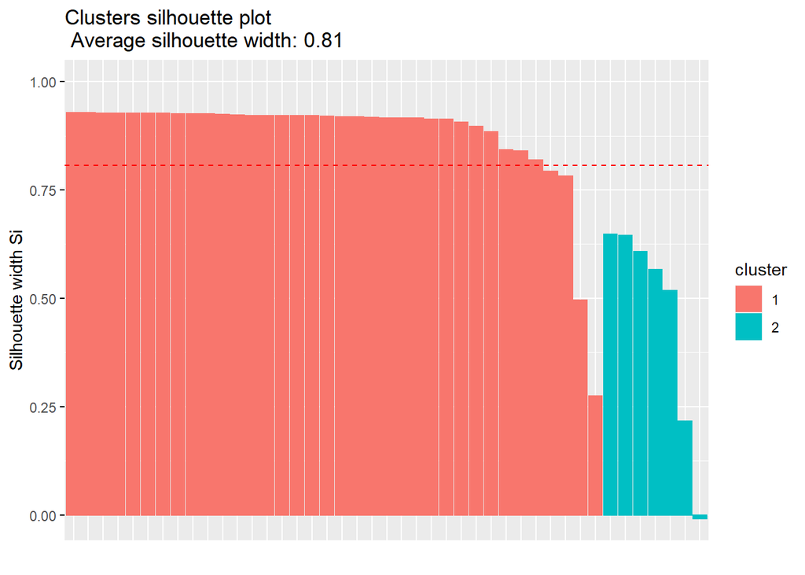

```r
fviz_silhouette(pam_jap1)
```

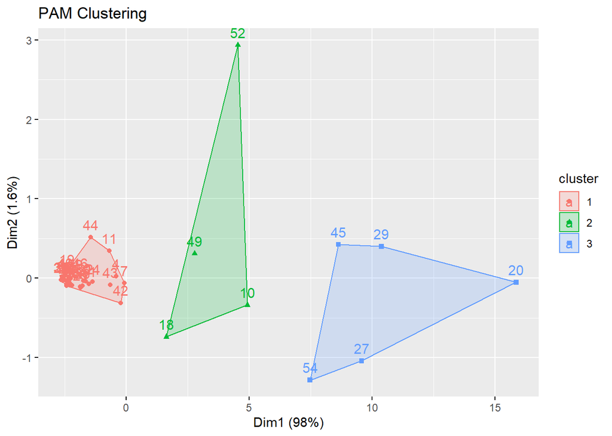

```r
pam_jap2<-eclust(data_no_japan, "pam", k=3, hc_metric="euclidean")
```

```
##   cluster size ave.sil.width
## 1       1   34          0.84
## 2       2    4          0.41
## 3       3    5          0.40
```

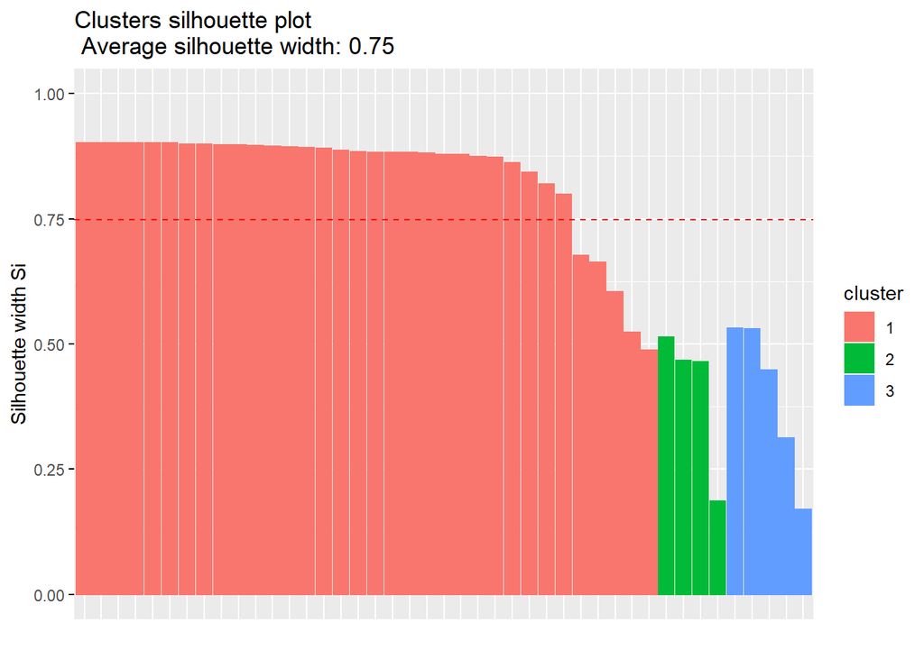

```r
fviz_silhouette(pam_jap2)
```

```r
pam_jap2$cluster
```

```
##  1  4  5  6  7  9 10 11 13 14 15 16 17 18 19 20 21 22 23 25 26 27 29 30 31 32
##  1  1  1  1  1  1  2  1  1  1  1  1  1  2  1  3  1  1  1  1  1  3  3  1  1  1
## 33 36 39 40 41 42 43 44 45 46 47 48 49 50 51 52 54
##  1  1  1  1  1  1  1  1  3  1  1  1  2  1  1  2  3
```

To see the difference in number of clusters we one again used Calinski-Harabasz index.

```r
round(calinhara(data_no_japan, pam_jap1$cluster),digits=2)
```

```
## [1] 164.7
```

```r
round(calinhara(data_no_japan, pam_jap2$cluster),digits=2)
```

```
## [1] 177.7
```

As we can see values of CH index are lower than for scenario with the outlier. However based on them we can conclude that more clusters (in this case 3 clusters) can be a better option.

#### Predictions

Let’s see if the algorithm can accurately predict in which cluster one additional observation will belong. Test observations were also number 19 (Georgia) and 27 (Italy).

```r
# full dataset
pam.full<-pam(set.full, k=4)

# train dataset
pam.train<-pam(set.train, k=4)

pam.train.kcca<-as.kcca(pam.train, set.train)
pam.pred<-predict(pam.train.kcca, set.test)
pam.pred
```

```
## 19 27
##  1  3
```

As we can see 19th observation is assigned to cluster 1 and 27th is to 3, which is consistent with clustering all observations. This means that PAM algorithm works better for prediction than K-Means.

### Conclusions

As it turned out analyzed data set was hard to conduct clustering due to the fact that there was one group of observations that were very similar and a few more that did not belong to this group. This caused difficulties with separation. Additionally another factor was number of observations that was 44 which is very small.  
The tests that were conducted indicated opposite conclusions.  
The result showed that PAM algorithm was better in predicting which cluster new observation will be assigned to. This gives a basis of the further analysis and to try another ways of dealing with this kind of data, which can be difficult to analyze. Additionally in case of clustering this data set the outliers aren’t a big problem, cause they create their own cluster. Value of average silhouette width was smaller, but it is only because of this one observation that was in it’s own cluster what decreased the value. Not all the data sets, even if they are clusterable can be managed with the methods mentioned above. The results that were given here were not good enough which can lead to wrong conclusions. I am aware of all the problems however this gives a good base to try the analysis on a different data set.